# General heatmap of mouse cortex E17.5

`r`r library(COTAN) library(ggplot2) library(ComplexHeatmap) library(circlize) library(cowplot)

The general heatmap can be done by the automatic function or extracting the information. In the first case we can plot a simmetric plot or an asymmetric one.

```
[1] \ploting a general heatmap\
[1] \Reln\   \Satb2\  \Sox5\   \Bcl11b\
[1] \Get p-values on a set of genes on columns genome wide on rows\
[1] \Using function S\
[1] \function to generate S \
```

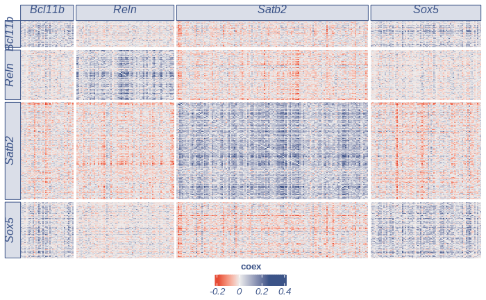

```
[1] \ploting a general heatmap\
[1] \Grm3\   \Abracl\ \Tox\    \Reln\   \Satb2\  \Sox5\   \Bcl11b\
[1] \Get p-values on a set of genes on columns genome wide on rows\
[1] \Using function S\
[1] \function to generate S \
```

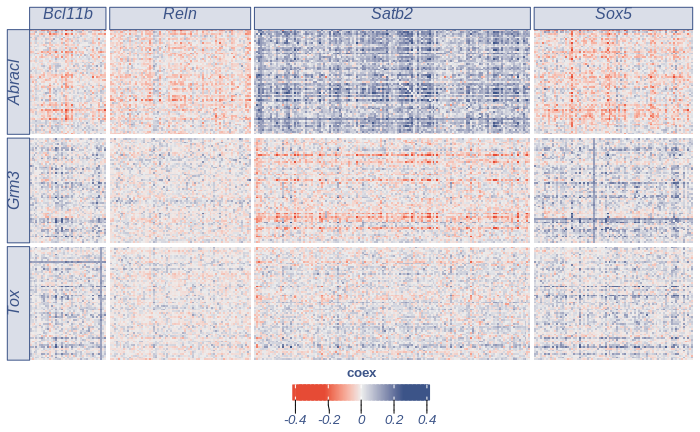

```
[1] \Satb2\  \Bcl11b\ \Sox5\   \Reln\
[1] \Get p-values on a set of genes on columns genome wide on rows\
[1] \Using function S\
[1] \function to generate S \
```

`r`r pos.link.Satb2 = rownames(p_value_17[p_value_17$Satb2 < 0.0001,])[rownames(p_value_17[p_value_17$Satb2 < 0.0001,]) %in% rownames(coex_17[coex_17$Satb2 > 0,])] pos.link.Bcl11b = rownames(p_value_17[p_value_17$Bcl11b < 0.001,])[rownames(p_value_17[p_value_17$Bcl11b < 0.001,]) %in% rownames(coex_17[coex_17$Bcl11b > 0,])] pos.link.Reln = rownames(p_value_17[p_value_17$Reln < 0.0001,])[rownames(p_value_17[p_value_17$Reln < 0.0001,]) %in% rownames(coex_17[coex_17$Reln > 0,])]

pos.link.Sox5 = rownames(p_value_17[p_value_17$Sox5 < 0.0001,])[rownames(p_value_17[p_value_17$Sox5 < 0.0001,]) %in% rownames(coex_17[coex_17$Sox5 > 0,])]

cl.genes$gene = as.vector(cl.genes$gene) length(c(pos.link.Bcl11b,pos.link.Reln,pos.link.Sox5,pos.link.Satb2))

```
[1] 184
```

This is the number of total secondary markers extracted.

`r`r dupl.genes = c(pos.link.Bcl11b,pos.link.Reln,pos.link.Sox5,pos.link.Satb2)[duplicated(c(pos.link.Bcl11b,pos.link.Reln,pos.link.Sox5,pos.link.Satb2))]

all.genes.to.plot = c(pos.link.Reln,pos.link.Satb2,pos.link.Bcl11b,pos.link.Sox5) all.genes.to.plot = all.genes.to.plot[!all.genes.to.plot %in% dupl.genes]

cl.genes= cl.genes[!cl.genes$gene %in% dupl.genes,]

```
[1] \Duplicated genes: 7 Plotted genes: 170\
```

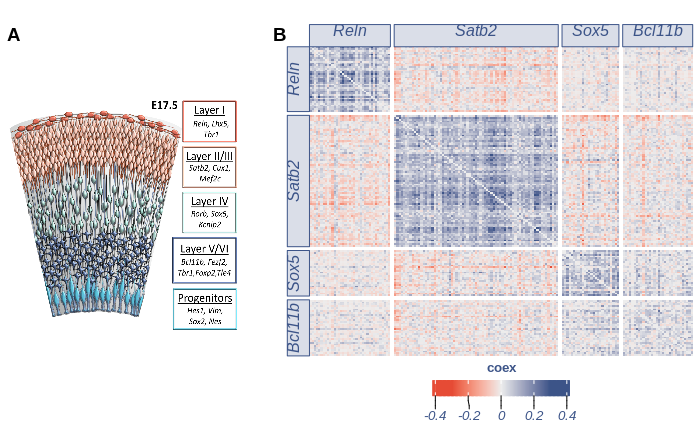